# Electronic Patient Tracking System Data Quality Assessments (ePTS DQA)

### 3.4.3 Quality issues related to **data entry error** by provinceby variable in each province

For issues related with data entry error, the majority of health facilities across provinces had issues od data entry errors less than 15%, with some stand out issues related with Height, CD4 date in Cabo Delgado, STI screening in Nampula, TB treatment in Zambezia, Inhambane and Maputo province, and IMC in Sofala, Inhambane and Maputo province respectively.

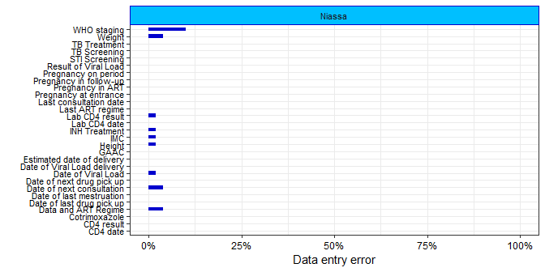

Figure 3.24: Figure 6.3: Percentage of data entry error in Niassa

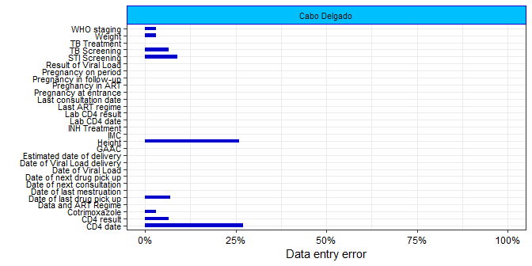

Figure 3.25: Figure 6.3: Percentage of data entry error in Cabo Delgado

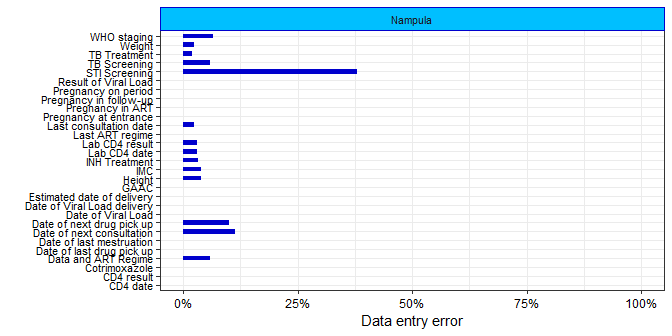

Figure 3.26: Figure 6.3: Percentage of data entry error in Nampula

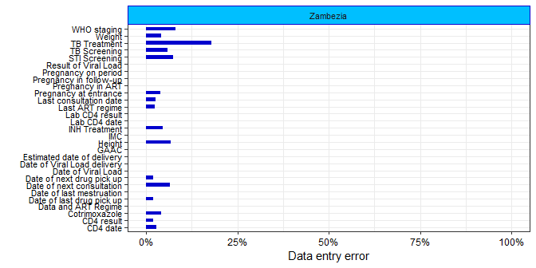

Figure 3.27: Figure 6.3: Percentage of data entry error in Zambezia

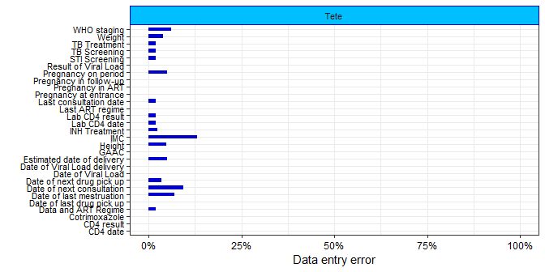

Figure 3.28: Figure 6.3: Percentage of data entry error in Tete

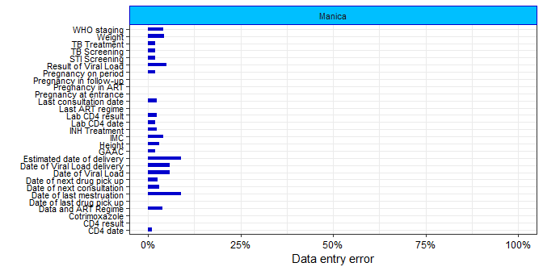

Figure 3.29: Figure 6.3: Percentage of data entry error in Manica

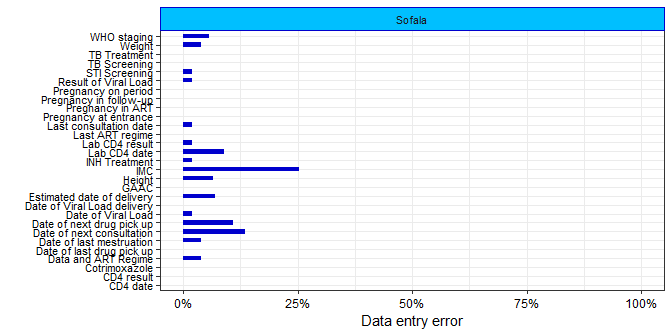

Figure 3.30: Figure 6.3: Percentage of data entry error in Sofala

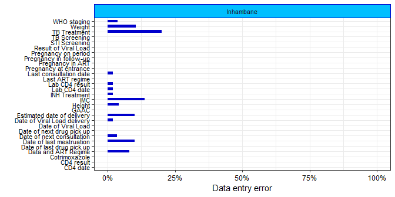

Figure 3.31: Figure 6.3: Percentage of data entry error in Inhambane

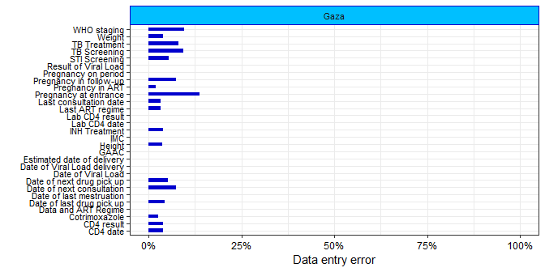

Figure 3.32: Figure 6.3: Percentage of data entry error in Gaza

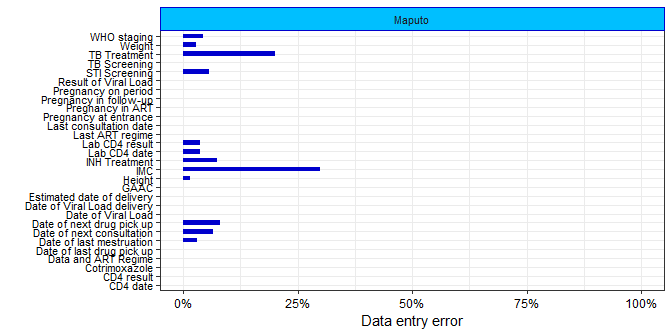

Figure 3.33: Figure 6.3: Percentage of data entry error in Maputo province

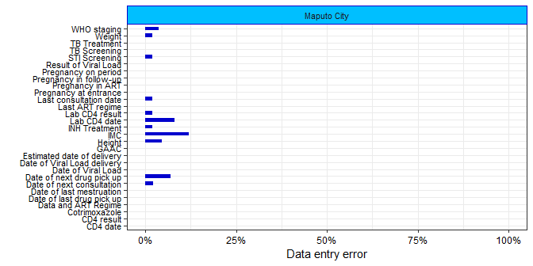

Figure 3.34: Figure 6.3: Percentage of data entry error in Maputo City

# 4 Discussion

Quality data is essential to benchmark and monitor progress to archiving care and treatment targets in the worldwide push to achieve epidemic control. Mozambique relies on paper-based systems as the primary sources for data collection and reporting. As EPTS coverage is rapidly scaled up, routine assessment of the completeness, accuracy and timeliness of retrospective data entry takes on critical importance. Results from the last round of data quality assessments on electronic patient tracking system showed a range of good quality data across health facilities and provinces, meaning that the majority of health facilities assessed there was concordance greater than 90% from data entered into the electronic system with data from patient charts. But there were some facilities mainly in Gaza and Tete provinces which highlighted some problems in concordance of data from electronic system and patient charts.

In terms of programmatic effect, there will be a greater implication related to the quality of data that is reported and used in decision making based on electronic systems. Considering that there were several factors related to documentation error with providers not filling in all information during the consultation with the patients, with data clerk not entering all the information that appears in the patients’ files to the electronic database and some lack of attention during data entry phase that may cause data entry errors. Therefore, during the cross-check of information entered into the system with the one that was manually collected, would rise some concerns on discrepancies during the reporting period, and this would have implications in decisions to be made based on data collected into the electronic system.

# 5 Conclusion

The lessons learned from this assessment were that professionals staff and providers should be cognizant of the possible discrepancies between paper and electronic information and look toward combining information from both records whenever appropriate. Most of health facilities still have the agreement of the existing data in the patient files and the data in the electronic patient tracking system, though, some health facilities in two provinces still poses some challenges on data stored in electronic systems, when compared with paper-based records.

Quality issues related with documentation of information into the patient files and lack of data entry into the system, where the major issues found on this evaluation. This was highlighted in areas related to laboratoty area of not being able to register the date of sample collection, result and date of delivering the viral load results, as well as the PMTCT area for not being able to register the fields related to estimated date of delivery, date of last menstruation, pregnancy in ART.

# 6 References

Consulting, A. A. 2009. “Health Information Systems in Developing Countries.”

Gimbel, S., Micek M., Lambdin B., Lara J., Karagianis M., Cuembelo F., and K Sherr. 2011. “An Assessment of Routine Primary Care Health Information System Data Quality in Sofala Province, Mozambique.” *Population Health Metrics* 12 (9): 9–12. https://doi.org/10.1186/1478-7954-9-12.

Powell, A., Davies H., and R. Thomson. 2003. “Using Routine Comparative Data to Assess the Quality of Health Care: Understanding and Avoiding Common Pitfalls.” *Quality & Safety in Health Care* 2 (12): 122–28. https://doi.org/10.1136/qhc.12.2.122.

Weiskopf, N. G., and C. Weng. 2013. “Methods and Dimensions of Electronic Health Record Data Quality Assessment: Enabling Reuse for Clinical Research.” *Journal of the American Medical Informatics Association* 1 (20): 144–51. https://doi.org/10.1136/amiajnl-2011-000681.

[^1]: File shared CDC containing EPTS versions in use by Health Units on January 16, 2018
[^2]: Data of volume of patients in ART shared by HIV program.